# Claw analysis

Andrew L Jackson

Attempt to get to the bottom of the data patterns and Kerry’s concerns.

## Setup

```r
library(SIBER)
library(tidyverse)
```

## Import data

```r
data <- read_csv("SI 18MAR22 TipBaseMid.csv")
names(data)
```

```
[1] "iso1"      "iso2"      "group"     "community" "Sex_Age"
```

```r
claw_df <- as.data.frame(select(data, iso1, iso2, group, community))
```

## Plot the raw data

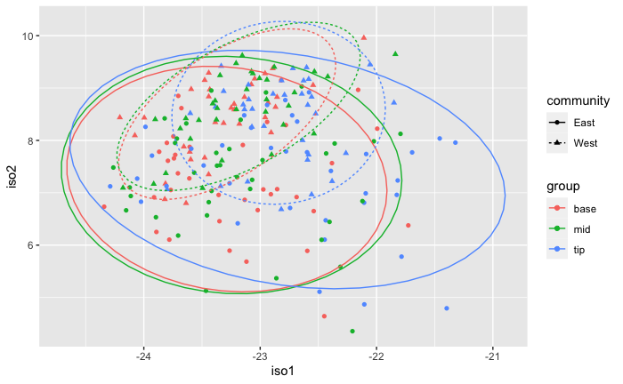

```r
g1 <- ggplot(data = claw_df,
             mapping = aes(x = iso1, y = iso2,
                           color = group,
                           shape = community)) +
  geom_point() +
  stat_ellipse(aes(linetype = community))

print(g1)
```

## Imoprt to SIBER and generate some basic stats

```r
siber_claw$sample.sizes
```

[output not shown]

```
     base mid tip
East   37  37  37
West   34  34  34
```

plot the siber object to visualise both the community and group data to make sense of the statistics

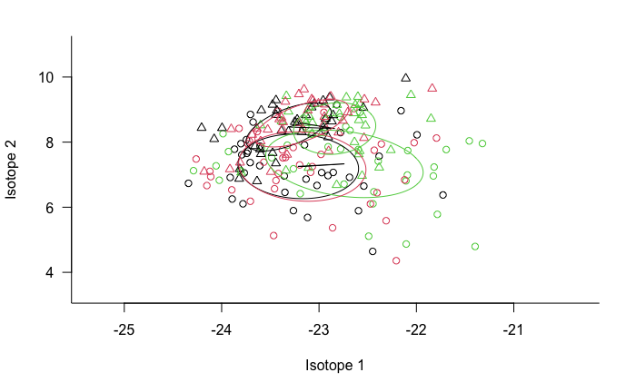

```r
plotSiberObject(siber_claw,
                hulls = TRUE,
                ellipses = TRUE)
```

From this is appears that the East community of points has a larger triangle joining the midpoints of its three ellipses compared with the West community which is so small its practically a line. This suggests that almost all the community metrics will be larger for East than West. The community metrics are based on the mid-points of each group within a community, not the entire set of points that make up that community: the reasons for this are articulated in the original paper.

## Thoughts

```r
list_claw <- claw_df %>%
  split(interaction(.$group, .$community)) #%>% map(laymanMetrics(x = .$iso1, y = .$iso2))


group_layman <- vector("list", length(list_claw))
names(group_layman) <- names(list_claw)

for (i in 1:length(list_claw)){

  tmp <- list_claw[[i]]
  group_layman[[i]] <- laymanMetrics(tmp$iso1, tmp$iso2)


}
```